# Quiz 230904

# 제출 시간의 분포

과제 제출이 제출 기간 마지막 날에 몰린다는 것을 시각적으로 보여주고 싶어서 하나 추가하였습니다. 아직은 학기초라 덜 한데, 중반 이후가 되면 마지막 날, 그것도 오후2시부터 몰리는 현상을 관찰할 수 있습니다. 여기서조차 랜덤화 효과를 관찰할 수 있네요. p-value 에 유의해 주세요. 제출시간과 관련한 두 가지 현상에 대해서도 여러분의 생각을 들어보고 싶습니다. 첫째, 랜덤화 효과. 둘쨰, 마감날에 몰리는 현상.

## 일 단위 마감 시간으로부터 제출 시간의 분포

### 분포표

일 단위

|  | [0,1] | (1,2] | (2,3] | (3,4] | (4,5] | (5,6] | (6,7] | (7,8] | (8,9] | (9,10] | (10,11] | (11,12] | (12,13] | (13,14] |
| --- | --- | --- | --- | --- | --- | --- | --- | --- | --- | --- | --- | --- | --- | --- |
| **Red** | 69 | 11 | 15 | 4 | 7 | 15 | 16 | 76 | 44 | 35 | 22 | 35 | 42 | 44 |
| **Black** | 62 | 16 | 14 | 3 | 13 | 12 | 11 | 54 | 50 | 35 | 28 | 44 | 36 | 37 |

Pearson’s Chi-squared test with simulated p-value (based on 2000 replicates): `.`

| Test statistic | df | P value |
| --- | --- | --- |
| 10.99 | NA | 0.6277 |

### 막대그래프

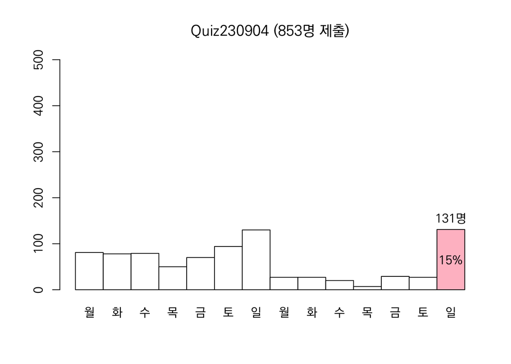

### Mosaic Plot

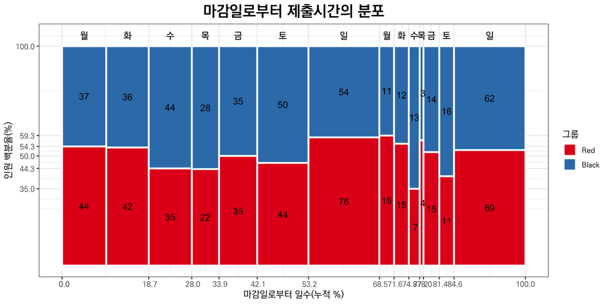